# Introduction to Text Analysis in R

Christian Staal Bruun Overgaard

April 25, 2023

Analyzing text in R is a lot of fun. This tutorial gets you started with some of the basics. You’ll learn:

- How to search for a specific word to identify all the messages in a dataset that mention that word
- How to identify the most frequent words in a given dataset
- How to visualize word frequencies using bar charts and word clouds

## Load packages

First, let’s load the relevant packages. If you haven’t installed them already, you’ll need to do that first, using the `install.packages()` function:

```r
#install.packages("readr")
#install.packages("readxl")
```

Let’s load the packages we need:

```r
library(readr) #for reading csv's
library(readxl) #for reading Excel sheets
library(tidytext) #main package for text analysis
library(tidyverse) #collection of useful packages, including ggplot
library(ggthemes) #for customizing ggplots
library(wordcloud) #for making word clouds
```

## Import Data

Next, we import the data. In this tutorial, we’ll work with a dataset that consists of 30,000 tweets about COVID-19, posted between January and May in 2020.

```r
### LOAD DATA FROM EXCEL SHEET
df <- readxl::read_excel("30K_tweets_COVID_for_tutorial.xlsx")

### IF YOU WANTED TO LOAD FROM A .CSV
#df <- readr::read_csv("30K_tweets_COVID_for_tutorial.csv")

head(df) #see what the data looks like
```

```
## # A tibble: 6 × 2
##      id text
##   <dbl> <chr>
## 1     1 "@TheDemCoalition @BarackObama @realDonaldTrump @BarackObama Warned don…
## 2     2 "Trump Laid the Groundwork for a Coronavirus Mess https://t.co/QYPj9uOe…
## 3     3 "In the face of a potential infectious disease outbreak, you want credi…
## 4     4 "Fact check: McConnell claims Obama didn't leave Trump a pandemic 'game…
## 5     5 "Coronavirus quarantine hits MORE of Trump's inner circle as Mulvaney j…
## 6     6 "Government Accountability Office To Investigate Trump Administration’s…
```

```r
glimpse(df) #alternative way to inspect the dataframe
```

```
## Rows: 30,000
## Columns: 2
## $ id   <dbl> 1, 2, 3, 4, 5, 6, 7, 8, 9, 10, 11, 12, 13, 14, 15, 16, 17, 18, 19…
## $ text <chr> "@TheDemCoalition @BarackObama @realDonaldTrump @BarackObama Warn…
```

## Subsetting data

Before doing any analyses, it’s often beneficial to process the data. Let’s start by subsetting.

### Use a single word to subset

If you want to only look at tweets that mention a specific word (let’s say “coronavirus”), you can use the `grepl()` function:

```r
df_cov <- df[grepl("Coronavirus"
                     , df$text, ignore.case=TRUE),]

df_cov19 <- df[grepl("COVID-19"
                     , df$text, ignore.case=TRUE),]
```

What if we wanted all tweets that mention BOTH of these words, or EITHER of them? We could modify the prior code like this:

```r
### mentions either
df_either <- df[grepl("Coronavirus|COVID-19"   #the vertical line means "or"
                     , df$text, ignore.case=TRUE),]

### mentions both
df_both <- df[grepl("Coronavirus", df$text, ignore.case=T) &
                          grepl("COVID-19", df$text, ignore.case=T) ,]

df_both$text[2] #look at the second message; see that it indeed mentions BOTH
```

```
## [1] "@tedlieu @WhiteHouse Actually, the specific coronavirus this time is called SARS-Cov-2. It causes Covid-19, the disease."
```

### Use regular expressions to subset

What if we wanted not only “Coronavirus” but also just instances of “Corona” to be included? Or what if we wanted both “COVID-19” and just “COVID”? In that case, we could use *regular expressions*:

```r
df_all <- df[grepl("Corona*|COVID*"   #the symbol * means "anything"
                     , df$text, ignore.case=TRUE),]

### See how many more tweets this approach keeps as compared to the prior approach:
nrow(df_either)
```

```
## [1] 17395
```

```r
nrow(df_all)
```

```
## [1] 20557
```

In this tutorial, we’ll examine tweets that mentioned either, so we’ll use the dataframe called “df_all” in the next step below.

## Working with the `TidyText` package

### Transform data to relevant structures

For most text analysis tasks, you need to process the data before analyzing it. One of the most common and useful ways to that is called *tokenizing*, where you split text messages consisting of longer text into smaller units (called “tokens”). In today’s examples, tokens will mostly be individual words (but they could also be other things, like numbers; “20” would be a token).

#### Tokenizing

`TidyText` has a neat function, `unnest_tokens()`, that makes it easy to tokenize your text data.

```r
df_tkn <- df_all %>% unnest_tokens(word, text) #can include the additional argument "to_lower = TRUE" if you don't want to distinguish between uppercase and lowercase.
df_tkn #our new object
```

```
## # A tibble: 593,550 × 2
##       id word
##    <dbl> <chr>
##  1     2 trump
##  2     2 laid
##  3     2 the
##  4     2 groundwork
##  5     2 for
##  6     2 a
##  7     2 coronavirus
##  8     2 mess
##  9     2 https
## 10     2 t.co
## # ℹ 593,540 more rows
```

```r
#id refers to post-number; so each post is broken down to individual words
```

Let’s see which words are very common in this document:

```r
df_tkn %>%
  dplyr::count(word, sort = TRUE)
```

```
## # A tibble: 48,290 × 2
##    word            n
##    <chr>       <int>
##  1 the         22459
##  2 t.co        15529
##  3 to          15514
##  4 https       15495
##  5 coronavirus 14405
##  6 trump       12708
##  7 of           8945
##  8 and          8814
##  9 a            8262
## 10 is           7035
## # ℹ 48,280 more rows
```

#### Removing “stopwords”

We see that words like “to”, “a”, and “of” appear frequently. That’s common. These are called “stopwords” and for many types of basic text analysis it is useful to remove them. `TidyText` comes pre-loaded with a list of common stopwords (conveniently called “stop_words”). Let’s take a look of the first ten words included in that list:

```r
stop_words
```

```
## # A tibble: 1,149 × 2
##    word        lexicon
##    <chr>       <chr>
##  1 a           SMART
##  2 a's         SMART
##  3 able        SMART
##  4 about       SMART
##  5 above       SMART
##  6 according   SMART
##  7 accordingly SMART
##  8 across      SMART
##  9 actually    SMART
## 10 after       SMART
## # ℹ 1,139 more rows
```

```r
stop_words |> head(5)
```

```
## # A tibble: 5 × 2
##   word  lexicon
##   <chr> <chr>
## 1 a     SMART
## 2 a's   SMART
## 3 able  SMART
## 4 about SMART
## 5 above SMART
```

To remove the stopwords from our tokenized dataset, we can use the `anti_join()` function:

```r
df_no_stopwords <- df_tkn %>%
  anti_join(stop_words)
### and then we can do the count again:
df_no_stopwords %>%
  dplyr::count(word, sort = TRUE)
```

```
## # A tibble: 47,614 × 2
##    word                n
##    <chr>           <int>
##  1 t.co            15529
##  2 https           15495
##  3 coronavirus     14405
##  4 trump           12708
##  5 covid            5630
##  6 19               4258
##  7 president        1952
##  8 amp              1880
##  9 realdonaldtrump  1807
## 10 people           1718
## # ℹ 47,604 more rows
```

Now, the stopwords are removed but the words “https” and “t.co” are still there, and they are not very useful (for what we’ll be doing in today’s tutorial). To remove them, we can modify the stopwords dictionary to include these words:

```r
### make dataframe with additional words we want to remove
additional_stopwords <- data.frame(word = c("https", "t.co", "19"), lexicon = "custom")

### combine the additional stopwords with tidytext's original list of stopwords:
all_my_stopwords <- rbind(stop_words, additional_stopwords)
tail(all_my_stopwords, 10) #look at the bottom 10 words in all_my_stopwords
```

```
## # A tibble: 10 × 2
##    word     lexicon
##    <chr>    <chr>
##  1 yet      onix
##  2 you      onix
##  3 young    onix
##  4 younger  onix
##  5 youngest onix
##  6 your     onix
##  7 yours    onix
##  8 https    custom
##  9 t.co     custom
## 10 19       custom
```

With that taken care of, we can repeat the steps from above to ensure all the relevant stopwords are removed:

```r
df_final <- df_tkn %>%
  anti_join(all_my_stopwords)
df_final %>%
  dplyr::count(word, sort = TRUE)
```

```
## # A tibble: 47,611 × 2
##    word                n
##    <chr>           <int>
##  1 coronavirus     14405
##  2 trump           12708
##  3 covid            5630
##  4 president        1952
##  5 amp              1880
##  6 realdonaldtrump  1807
##  7 people           1718
##  8 virus            1602
##  9 pandemic         1546
## 10 house            1534
## # ℹ 47,601 more rows
```

Now, we’re left with only the relevant words.

### Visualizing common words

Instead of listing this as a table, we can make it more reader-friendly and compelling by visualizing it. Today, we’ll focus on two popular ways of doing this: bar charts and word clouds.

#### Bar chart

Before making a bar chart, we need to filter the data to only include words that appear frequently enough that we want them in our visualization:

```r
df_filtered <- df_final %>%
  dplyr::count(word, sort = TRUE) %>% #this is the same step as before
  filter(n > 1200) %>% #decide how frequently a word must appear to be included
  mutate(word = reorder(word, n))     # to make the bar graph ordered

df_filtered
```

```
## # A tibble: 13 × 2
##    word                n
##    <fct>           <int>
##  1 coronavirus     14405
##  2 trump           12708
##  3 covid            5630
##  4 president        1952
##  5 amp              1880
##  6 realdonaldtrump  1807
##  7 people           1718
##  8 virus            1602
##  9 pandemic         1546
## 10 house            1534
## 11 response         1431
## 12 covid19          1289
## 13 white            1289
```

Then, we can use the object we just created, *df_filtered*, in combination with `ggplot`, a powerful data visualization package that is a part of the Tidyverse.

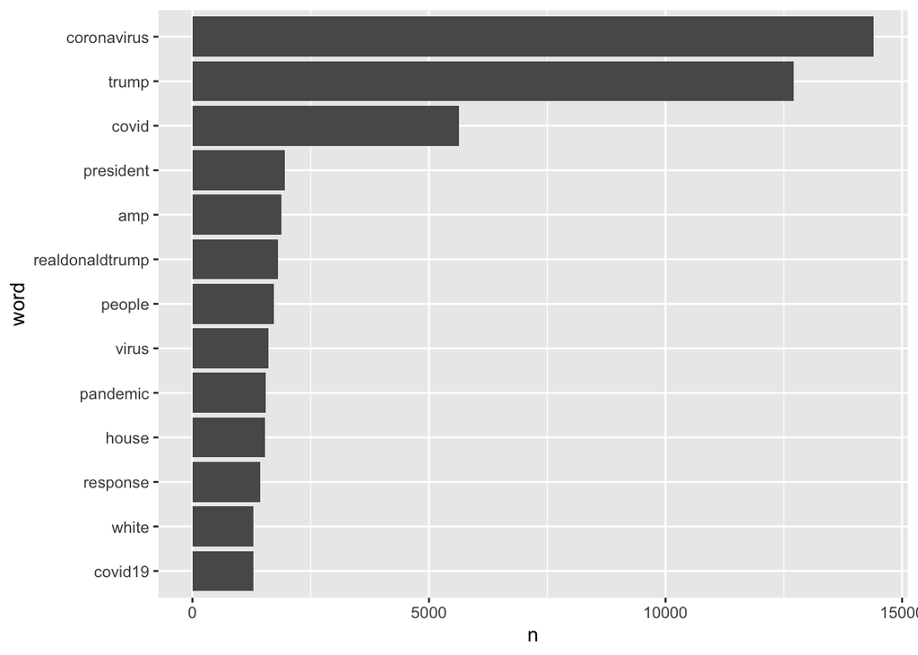

```r
(myplot <- df_filtered %>%
  ggplot(aes(word, n)) + #use ggplot
  geom_col() +
  coord_flip()    ) #change bars to horizontal to work better with words
```

You can change make the plot look nicer by adding some labels and a theme:

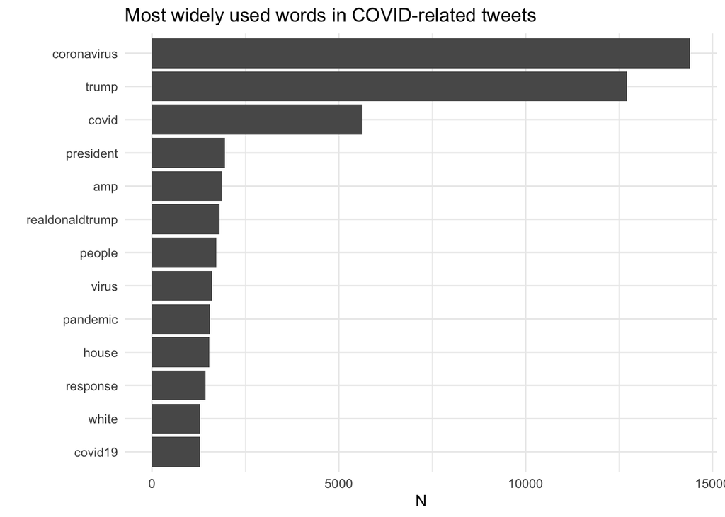

```r
myplot +
  labs(
        title="Most widely used words in COVID-related tweets",
        x ="",
        y = "N") + #remember: X and Y has been flipped
  theme_minimal()
```

##### Word cloud

Another possibility is to make a word cloud using the `wordcloud` package:

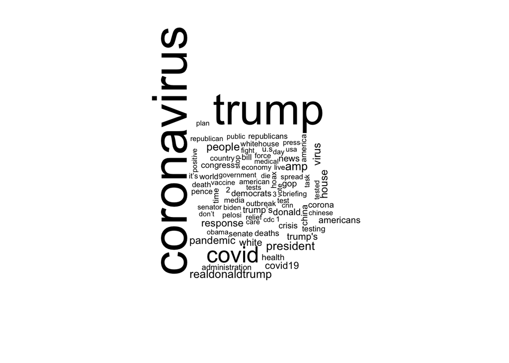

```r
set.seed(3) #changing this number will change what the word cloud looks like

df_final %>%
  dplyr::count(word, sort = TRUE) %>% #same count as before
  with(wordcloud::wordcloud(word, n, max.words = 80
                            #, colors = c("blue", "red", "yellow"), #optional!
                          #  random.color=T #optional
                            ))
```